# Análise das Séries Temporais de Amostras do Rio Doce - Manganês total e Turbidez

Elisa Fink

2023-09-05

O presente relatório tem por objetivo analisar amostras de água coletadas em três estações do Rio Doce, a partir dos dados de monitoramento contínuo do Instituto Mineiro de Gestão das Águas (IGAM), durante os anos de 2012 a 2021, para os analitos Manganês total e Turbidez.

## 1. PRINCIPAL

### Parte a) importação dos bancos de dados

Os bancos foram lidos com o seguinte código:

```r
# LER OS BANCOS DE DADOS
library(readxl)
X2012_2016 <- read_excel("Dados/2012_2016.xls", sheet = "Doce")
X2017 <- read_excel("Dados/2017.xlsx", sheet = "Doce")
X2018_1trimestre <- read_excel("Dados/2018_1trimestre.xlsx", sheet = "Doce")
X2018_2trimestre <- read_excel("Dados/2018_2trimestre.xlsx", sheet = "Doce")
X2018_3trimestre <- read_excel("Dados/2018_3trimestre.xlsx", sheet = "Doce")
X2018_4trimestre <- read_excel("Dados/2018_4trimestre.xlsx", sheet = "Doce")
X2019_1trimestre <- read_excel("Dados/2019_1trimestre.xlsx", sheet = "Doce")
X2019_2trimestre <- read_excel("Dados/2019_2trimestre.xls", sheet = "Doce")
X2019_3trimestre <- read_excel("Dados/2019_3trimestre.xlsx", sheet = "Doce")
X2019_4trimestre <- read_excel("Dados/2019_4trimestre.xlsx", sheet = "Doce")
X2020_1trimestre <- read_excel("Dados/2020_1trimestre.xlsx")
X2020_2trimestre <- read_excel("Dados/2020_2trimestre.xlsx")
X2020_3e4trimestres <- read_excel("Dados/2020_3e4trimestres.xls", skip = 3)
X2021_1e2trimestres <- read_excel("Dados/2021_1e2trimestres.xls",  skip = 3)
X2021_3e4trimestres <- read_excel("Dados/2021_3e4trimestres.xls",  skip = 3)
```

Em seguida, as variáveis de interesse foram selecionadas com o código abaixo:

```r
# SELECIONAR SOMENTE AS VARIÁVEIS A SEREM ANALISADAS
X2012_2016 <- X2012_2016[,c(17:19, 130, 131, 202, 203)]
X2017 <- X2017[, c(12:14, 125, 126, 197, 198)]
X2018_1trimestre <- X2018_1trimestre[,c(17, 19:20, 131, 132, 203, 204)]
X2018_2trimestre <- X2018_2trimestre[,c(16:18, 129, 130, 201, 202)]
X2018_3trimestre <- X2018_3trimestre[,c(16:18, 129, 130, 201, 202)]
X2018_4trimestre <- X2018_4trimestre[,c(16:18, 129, 130, 201, 202)]
X2019_1trimestre <- X2019_1trimestre[,c(16:18, 129, 130, 201, 202)]
X2019_2trimestre <- X2019_2trimestre[,c(9:11, 122, 123, 194, 195)]
X2019_3trimestre <- X2019_3trimestre[,c(9:11, 122, 123, 194, 195)]
X2019_4trimestre <- X2019_4trimestre[,c(9:11, 124, 125, 198, 199)]
X2020_1trimestre <- X2020_1trimestre[,c(1:3, 116, 117, 190, 191)]
X2020_2trimestre <- X2020_2trimestre[,c(1:3, 116, 117, 190, 191)]
X2020_3e4trimestres <- X2020_3e4trimestres[,c(1:3, 116, 117, 190, 191)]
X2021_1e2trimestres <- X2021_1e2trimestres[,c(1:3, 116, 117, 190, 191)]
X2021_3e4trimestres <- X2021_3e4trimestres[,c(1:3, 116, 117, 190, 191)]
```

Por fim, com o código a seguir, foram unidos todos os bancos de dados, e foram filtradas as estações de monitoramento de interesse:

```r
#JUNÇÃO DAS TABELAS
tabela_completa <- rbind(X2012_2016, X2017, X2018_1trimestre, X2018_2trimestre, X2018_3trimestre, X2018_4trimestre, X2019_1trimestre, X2019_2trimestre, X2019_3trimestre, X2019_4trimestre, X2020_1trimestre, X2020_2trimestre, X2020_3e4trimestres, X2021_1e2trimestres, X2021_3e4trimestres)

### FILTRO DAS ESTAÇÕES
library(tidyverse)
tabela_filtrada<-tabela_completa%>%
  filter(Estação == "RD071" | Estação ==  "RD072" | Estação == "RD011")
```

Com o banco organizado, foi feito o tratamento dos valores abaixo do limite de detecção, conforme instruído.

```r
### TRATAMENTO DE <LDS:
tabela_filtrada[!is.na(tabela_filtrada$`Sinal Turbidez`),]$Turbidez <- tabela_filtrada[!is.na(tabela_filtrada$`Sinal Turbidez`),]$Turbidez /2
tabela_filtrada[!is.na(tabela_filtrada$`Sinal Manganês total`),]$`Manganês total`<- tabela_filtrada[!is.na(tabela_filtrada$`Sinal Manganês total`),]$`Manganês total` /2
```

Foi encontrada na variável Turbidez uma amostra abaixo do limite de detecção. Não foi encontrada nenhuma amostra abaixo do limite de detecção na variável Manganês Total.

Para o tratamento da amostra abaixo do limite de detecção (LD), foi utilizado o método de substituição por LD/2. Esse método é considerado razoável quando no máximo 15% das amostras estão abaixo do LD, caso do banco em análise. Quando mais de 15% das amostras estão abaixo do LD, essa substituição simples pode enviesar o cálculo da média e desvio padrão amostral.

Caso houvesse mais de 15% de amostras abaixo do LD no banco, minha sugestão seria utilizar a mesma substituição, porém com o uso de métodos não paramétricos ou um teste de proporção para prosseguir com a análise. O motivo dessa escolha é que os dados não seguem a distribuição normal e são extremamente assimétricos, o que viola pré-requisitos para outros métodos, como o Ajuste de Cohen e a Média Truncada. Abaixo, o histograma que mostra visualmente o problema dos dados:

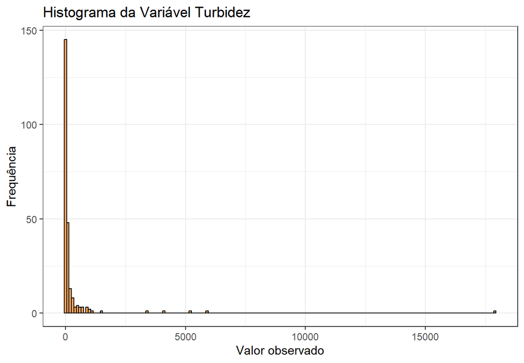

```r
ggplot(tabela_filtrada)+
  geom_histogram(mapping = aes(x = Turbidez), binwidth = 100, color = "black", fill = "sandybrown")+
  ggtitle("Histograma da Variável Turbidez")+
  xlab("Valor observado")+
  ylab("Frequência")+
  theme_bw()
```

### Parte b) análise exploratória dos dados:

Vamos iniciar a análise exploratória plotando as séries em estudo:

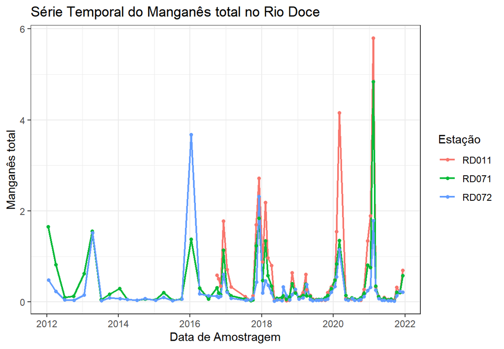

```r
### PLOT DA SÉRIE TEMPORAL

# manganês total

ggplot(tabela_filtrada[!is.na(tabela_filtrada$`Manganês total`),])+ ### a série apresenta descontinuidades nas linhas se plotada com NAs
  geom_line(mapping = aes(x = `Data de Amostragem`, y = `Manganês total`,  color = Estação), na.rm = TRUE, linewidth = .8)+
  geom_point(mapping = aes(x = `Data de Amostragem`, y = `Manganês total`,  color = Estação), size = 1.2)+
  ggtitle("Série Temporal do Manganês total no Rio Doce")+
  theme_bw()
```

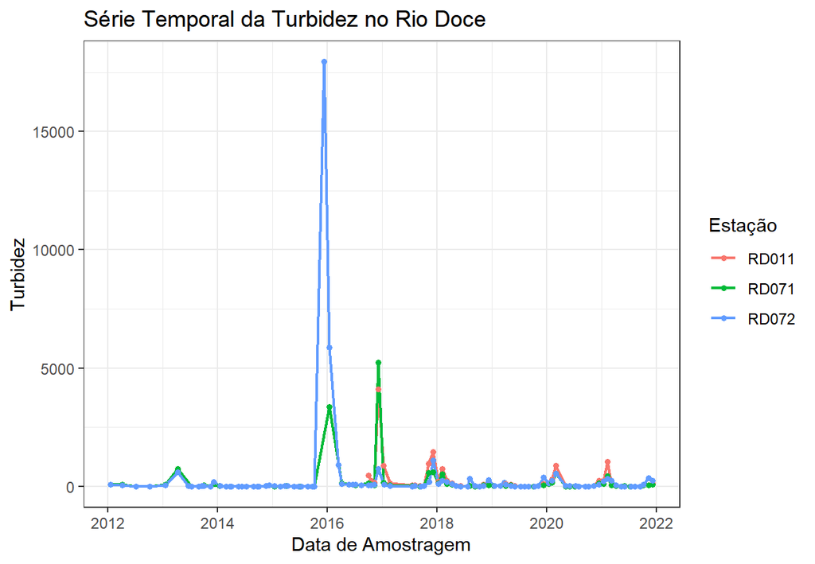

```r
# turbidez

ggplot(tabela_filtrada[!is.na(tabela_filtrada$Turbidez),])+ ### a série apresenta descontinuidades nas linhas se plotada com NAs
  geom_line(mapping = aes(x = `Data de Amostragem`, y = Turbidez,  color = Estação), na.rm = TRUE, linewidth = .8)+
  geom_point(mapping = aes(x = `Data de Amostragem`, y = Turbidez,  color = Estação), size = 1.2)+
  ggtitle("Série Temporal da Turbidez no Rio Doce")+
  theme_bw()
```

#### Presença de sazonalidade:

Através da inspeção visual dos dados, pode-se perceber um padrão que se repete nos diferentes anos observados, com os níveis de ambos os analitos aumentando durante os meses de verão. Por meio do teste de Friedman, é possível confirmar se há sazonalidade nos dados:

```r
#primeiramente removemos os NAs
turbidez = tabela_filtrada[!is.na(tabela_filtrada$Turbidez),]
manganes = tabela_filtrada[!is.na(tabela_filtrada$`Manganês total`),]
library(seastests)
```

Manganês - estação RD011:

```r
fried(manganes[manganes$Estação == "RD011",]$`Manganês total`, diff = F, freq = 12)
```

```
## Test used:  Friedman rank
##
## Test statistic:  28.85
## P-value:  0.002398089
```

Manganês - estação RD071:

```r
fried(manganes[manganes$Estação == "RD071",]$`Manganês total`, diff = F, freq = 12)
```

```
## Test used:  Friedman rank
##
## Test statistic:  32.97
## P-value:  0.0005312197
```

Manganês - estação RD072:

```r
fried(manganes[manganes$Estação == "RD072",]$`Manganês total`, diff = F, freq = 12)
```

```
## Test used:  Friedman rank
##
## Test statistic:  29.62
## P-value:  0.001820446
```

Turbidez - estação RD011:

```r
fried(turbidez[turbidez$Estação == "RD011",]$`Turbidez`, diff = F, freq = 12)
```

```
## Test used:  Friedman rank
##
## Test statistic:  26.73
## P-value:  0.005045388
```

Turbidez - estação RD071:

```r
fried(turbidez[turbidez$Estação == "RD071",]$`Turbidez`, diff = F, freq = 12)
```

```
## Test used:  Friedman rank
##
## Test statistic:  37.23
## P-value:  0.000105408
```

Turbidez - estação RD072:

```r
fried(turbidez[turbidez$Estação == "RD072",]$`Turbidez`, diff = F, freq = 12)
```

```
## Test used:  Friedman rank
##
## Test statistic:  9.44
## P-value:  0.5811354
```

O teste de friedman aponta a existência de forte sazonalidade em todas as estações para ambos os parâmetros, exceto a turbidez na estação RD072.

#### Presença de Tendência:

Será utilizado o teste de Mann-Kendall (descrito no material de referência) para a detecção de tendências de crescimento ou decrescimento nos parâmetros observados. Para realizar esse teste, primeiro verifica-se se as amostras em diferentes pontos de coleta são comparáveis, por meio de um teste de qui-quadrado, cuja estatística de teste é calculada com o código abaixo:

#### Manganês Total:

```r
library(trend)
TRD071<-mk.test(manganes[manganes$Estação == "RD071",]$`Manganês total`)
TRD072<-mk.test(manganes[manganes$Estação == "RD072",]$`Manganês total`)
TRD011<-mk.test(manganes[manganes$Estação == "RD011",]$`Manganês total`)
Z011<- TRD011$estimates[1]/sqrt(TRD011$estimates[2])
Z071<- TRD071$estimates[1]/sqrt(TRD071$estimates[2])
Z072<- TRD072$estimates[1]/sqrt(TRD072$estimates[2])
meanZ <- mean(c(Z011,Z071,Z072))
X2h<- (Z011^2 - 3*meanZ) + (Z071^2 - 3*meanZ) + (Z072^2 - 3*meanZ) #estatística de teste
X2h
```

```
##        S
## 8.919512
```

```r
qchisq(p = 0.95, df = 2, lower.tail = TRUE) # valor de chi para comparação
```

```
## [1] 5.991465
```

A estatística de teste é maior que o qui quadrado com 2 graus de liberdade e 5% de significância. Portanto, rejeitamos a hipótese nula de que os diferentes pontos de coleta são comparáveis entre si.

Portanto, vamos fazer os testes de tendência individualmente para cada ponto de coleta:

RD011:

```r
mk.test(manganes[manganes$Estação == "RD011",]$`Manganês total`)
```

```
##
##  Mann-Kendall trend test
##
## data:  manganes[manganes$Estação == "RD011", ]$`Manganês total`
## z = -1.2948, n = 59, p-value = 0.1954
## alternative hypothesis: true S is not equal to 0
## sample estimates:
##             S          varS           tau
##  -199.0000000 23383.6666667    -0.1163063
```

Não rejeitamos a hipótese nula de que não há tendência na série do analito Manganês Total no ponto de coleta RD011 (p = 0.20).

RD071:

```r
mk.test(manganes[manganes$Estação == "RD071",]$`Manganês total`)
```

```
##
##  Mann-Kendall trend test
##
## data:  manganes[manganes$Estação == "RD071", ]$`Manganês total`
## z = -0.41419, n = 78, p-value = 0.6787
## alternative hypothesis: true S is not equal to 0
## sample estimates:
##             S          varS           tau
## -9.700000e+01  5.372033e+04 -3.230103e-02
```

Não rejeitamos a hipótese nula de que não há tendência na série do analito Manganês Total no ponto de coleta RD071 (p = 0.67).

RD072:

```r
mk.test(manganes[manganes$Estação == "RD072",]$`Manganês total`)
```

```
##
##  Mann-Kendall trend test
##
## data:  manganes[manganes$Estação == "RD072", ]$`Manganês total`
## z = -0.53069, n = 78, p-value = 0.5956
## alternative hypothesis: true S is not equal to 0
## sample estimates:
##             S          varS           tau
## -1.240000e+02  5.371933e+04 -4.129892e-02
```

Não rejeitamos a hipótese nula de que não há tendência na série do analito Manganês Total no ponto de coleta RD072 (p = 0.60).

#### Turbidez:

```r
library(trend)
TRD071<-mk.test(turbidez[turbidez$Estação == "RD071",]$`Turbidez`)
TRD072<-mk.test(turbidez[turbidez$Estação == "RD072",]$`Turbidez`)
TRD011<-mk.test(turbidez[turbidez$Estação == "RD011",]$`Turbidez`)
Z011<- TRD011$estimates[1]/sqrt(TRD011$estimates[2])
Z071<- TRD071$estimates[1]/sqrt(TRD071$estimates[2])
Z072<- TRD072$estimates[1]/sqrt(TRD072$estimates[2])
meanZ <- mean(c(Z011,Z071,Z072))
X2h<- (Z011^2 - 3*meanZ) + (Z071^2 - 3*meanZ) + (Z072^2 - 3*meanZ) #estatística de teste
X2h
```

```
##        S
## 16.35855
```

```r
qchisq(p = 0.95, df = 2, lower.tail = TRUE) # valor de chi para comparação
```

```
## [1] 5.991465
```

A estatística de teste é maior que o qui quadrado com 2 graus de liberdade e 5% de significância. Portanto, rejeitamos a hipótese nula de que os diferentes pontos de coleta são comparáveis entre si.

Portanto, vamos fazer os testes de tendência individualmente para cada ponto de coleta:

RD011:

```r
mk.test(turbidez[turbidez$Estação == "RD011",]$`Turbidez`)
```

```
##
##  Mann-Kendall trend test
##
## data:  turbidez[turbidez$Estação == "RD011", ]$Turbidez
## z = -2.7073, n = 59, p-value = 0.006782
## alternative hypothesis: true S is not equal to 0
## sample estimates:
##             S          varS           tau
##  -415.0000000 23383.6666667    -0.2425482
```

Rejeitamos a hipótese nula de que não há tendência na série do analito Turbidez no ponto de coleta RD011 (p = 0.01). Há uma tendência negativa.

RD071:

```r
mk.test(turbidez[turbidez$Estação == "RD071",]$`Turbidez`)
```

```
##
##  Mann-Kendall trend test
##
## data:  turbidez[turbidez$Estação == "RD071", ]$Turbidez
## z = -0.80682, n = 78, p-value = 0.4198
## alternative hypothesis: true S is not equal to 0
## sample estimates:
##             S          varS           tau
## -1.880000e+02  5.371933e+04 -6.261449e-02
```

Não rejeitamos a hipótese nula de que não há tendência na série do analito Turbidez no ponto de coleta RD071 (p = 0.42).

RD072:

```r
mk.test(turbidez[turbidez$Estação == "RD072",]$`Turbidez`)
```

```
##
##  Mann-Kendall trend test
##
## data:  turbidez[turbidez$Estação == "RD072", ]$Turbidez
## z = 1.5989, n = 102, p-value = 0.1098
## alternative hypothesis: true S is not equal to 0
## sample estimates:
##            S         varS          tau
## 5.540000e+02 1.196167e+05 1.075624e-01
```

Não rejeitamos a hipótese nula de que não há tendência na série do analito Turbidez no ponto de coleta RD072 (p = 0.11).

### Parte c) limpeza em bases de dados reais:

Com o código abaixo, foi importado e visualizado o banco para essa parte da tarefa:

```r
library(readr)
dados_MG <- read_csv('Dados/Extra/dados_MG.csv', locale = locale(encoding = 'UTF-8'))
head(dados_MG[,1:4],20)
```

```
## # A tibble: 20 × 4
##    CO_MUNICIP CO_STATUS DS_NOME                   DS_NOMEPAD
##         <dbl> <chr>     <chr>                     <chr>
##  1     310000 IGNOR     "Município ignorado - MG" MUNICIPIO IGNORADO - MG
##  2     310010 ATIVO     "Abadia dos Dourados"     ABADIA DOS DOURADOS
##  3     310020 ATIVO     "Abaeté"                  ABAETE
##  4     310030 ATIVO     "Abre Campo"              ABRE CAMPO
##  5     310040 ATIVO     "Acaiaca"                 ACAIACA
##  6     310050 ATIVO     "Açucena"                 ACUCENA
##  7     310060 ATIVO     "Água Boa"                AGUA BOA
##  8     310080 ATIVO     "Aguanil"                 AGUANIL
##  9     310110 ATIVO     "Aimorés"                 AIMORES
## 10     310120 ATIVO     "Aiuruoca"                AIURUOCA
## 11     310130 ATIVO     "Alagoa"                  ALAGOA
## 12     310140 ATIVO     "Albertina"               ALBERTINA
## 13     310160 ATIVO     "Alfenas"                 ALFENAS
## 14     310163 ATIVO     "Alfredo Vasconcelos"     ALFREDO VASCONCELOS
## 15     310180 ATIVO     "Alpercata"               ALPERCATA
## 16     310190 ATIVO     "Alpinópolis"             ALPINOPOLIS
## 17     310200 ATIVO     "Alterosa"                ALTEROSA
## 18     310205 ATIVO     "Alto Capara\xf3"         ALTO CAPARAO
## 19     310210 ATIVO     "Alto Rio Doce"           ALTO RIO DOCE
## 20     310220 ATIVO     "Alvarenga"               ALVARENGA
```

Pode-se verificar na linha 18 que ocorreu um erro na leitura de uma palavra acentuada. Porém esse erro não ocorreu em todas as linhas com caracteres especiais do banco. Uma alternativa é tentar abrir o banco com uma codificação diferente:

```r
dados_MG.iso <- read_csv('Dados/Extra/dados_MG.csv', locale = locale(encoding = 'ISO-8859-1'))
head(dados_MG.iso[,1:4], 20)
```

```
## # A tibble: 20 × 4
##    CO_MUNICIP CO_STATUS DS_NOME                   DS_NOMEPAD
##         <dbl> <chr>     <chr>                     <chr>
##  1     310000 IGNOR     "MunicÃpio ignorado - MG" MUNICIPIO IGNORADO - MG
##  2     310010 ATIVO     "Abadia dos Dourados"     ABADIA DOS DOURADOS
##  3     310020 ATIVO     "AbaetÃ©"                 ABAETE
##  4     310030 ATIVO     "Abre Campo"              ABRE CAMPO
##  5     310040 ATIVO     "Acaiaca"                 ACAIACA
##  6     310050 ATIVO     "AÃ§ucena"                ACUCENA
##  7     310060 ATIVO     "Ã\u0081gua Boa"          AGUA BOA
##  8     310080 ATIVO     "Aguanil"                 AGUANIL
##  9     310110 ATIVO     "AimorÃ©s"                AIMORES
## 10     310120 ATIVO     "Aiuruoca"                AIURUOCA
## 11     310130 ATIVO     "Alagoa"                  ALAGOA
## 12     310140 ATIVO     "Albertina"               ALBERTINA
## 13     310160 ATIVO     "Alfenas"                 ALFENAS
## 14     310163 ATIVO     "Alfredo Vasconcelos"     ALFREDO VASCONCELOS
## 15     310180 ATIVO     "Alpercata"               ALPERCATA
## 16     310190 ATIVO     "AlpinÃ³polis"            ALPINOPOLIS
## 17     310200 ATIVO     "Alterosa"                ALTEROSA
## 18     310205 ATIVO     "Alto Caparaó"            ALTO CAPARAO
## 19     310210 ATIVO     "Alto Rio Doce"           ALTO RIO DOCE
## 20     310220 ATIVO     "Alvarenga"               ALVARENGA
```

Desta vez, a linha 18 foi lida corretamente, mas as outras linhas que estavam corretas antes agora estão erradas. Isso significa que há linhas com codificações diferentes no mesmo arquivo. Esse problema pode ter sido causado ao juntar dados de diferentes fontes no mesmo arquivo. Para resolvê-lo, será necessário trocar a codificação somente das variaveis que não estão em UTF-8. A função nchar() não consegue contar os caracteres de strings com erros de codificação, por isso, será utilizada para criar um vetor lógico que indica quais linhas não estão em UTF-8. Em seguida, esse vetor será utilizado para trocar essas linhas por suas equivalentes no banco lido com a codificação ISO-8859-1, que conseguiu lê-las corretamente:

```r
not.utf <- is.na(nchar(dados_MG$DS_NOME, allowNA=T))
dados_MG$DS_NOME[not.utf] <- dados_MG.iso$DS_NOME[not.utf]
head(dados_MG[,1:4],20)
```

```
## # A tibble: 20 × 4
##    CO_MUNICIP CO_STATUS DS_NOME                 DS_NOMEPAD
##         <dbl> <chr>     <chr>                   <chr>
##  1     310000 IGNOR     Município ignorado - MG MUNICIPIO IGNORADO - MG
##  2     310010 ATIVO     Abadia dos Dourados     ABADIA DOS DOURADOS
##  3     310020 ATIVO     Abaeté                  ABAETE
##  4     310030 ATIVO     Abre Campo              ABRE CAMPO
##  5     310040 ATIVO     Acaiaca                 ACAIACA
##  6     310050 ATIVO     Açucena                 ACUCENA
##  7     310060 ATIVO     Água Boa                AGUA BOA
##  8     310080 ATIVO     Aguanil                 AGUANIL
##  9     310110 ATIVO     Aimorés                 AIMORES
## 10     310120 ATIVO     Aiuruoca                AIURUOCA
## 11     310130 ATIVO     Alagoa                  ALAGOA
## 12     310140 ATIVO     Albertina               ALBERTINA
## 13     310160 ATIVO     Alfenas                 ALFENAS
## 14     310163 ATIVO     Alfredo Vasconcelos     ALFREDO VASCONCELOS
## 15     310180 ATIVO     Alpercata               ALPERCATA
## 16     310190 ATIVO     Alpinópolis             ALPINOPOLIS
## 17     310200 ATIVO     Alterosa                ALTEROSA
## 18     310205 ATIVO     Alto Caparaó            ALTO CAPARAO
## 19     310210 ATIVO     Alto Rio Doce           ALTO RIO DOCE
## 20     310220 ATIVO     Alvarenga               ALVARENGA
```

Agora, todos os dados estão corretos.

## 2. DESAFIO

```r
#10/12/2020
library(tidyverse)
turbidez <- turbidez %>%
   add_row(Estação = "RD011", `Data de Amostragem` = as.Date("2020-12-10"), .before = 191)
```

```r
library(imputeTS)

serie_imputada <- data.frame(Turbidez = round(na_interpolation(turbidez[turbidez$Estação == "RD011",]$Turbidez,option="spline"),3), `Data de Amostragem` = turbidez[turbidez$Estação == "RD011",]$`Data de Amostragem`)
```

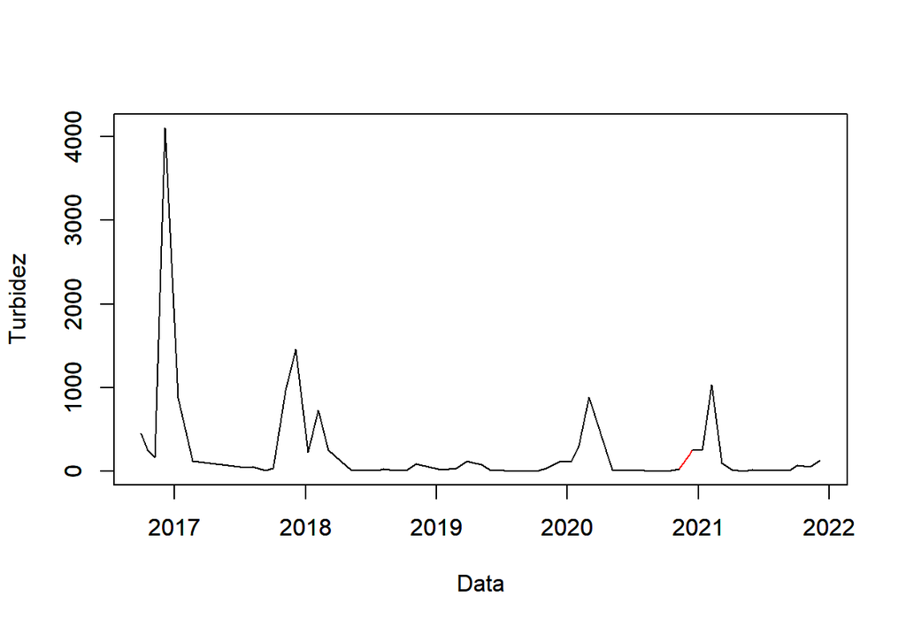

```r
plot(x = serie_imputada$Data.de.Amostragem, y = serie_imputada$Turbidez, type = "l", col = "red", lwd = 1, ylab = "Turbidez", xlab = "Data")
par(new=TRUE)
plot(x = turbidez[turbidez$Estação == "RD011",]$`Data de Amostragem`, y = turbidez[turbidez$Estação == "RD011",]$Turbidez, lwd = 1, type = "l", xlab = "", ylab = "")
```

Em vermelho, podemos visualizar a imputação gerada pelo método de splines. O valor representativo para a data de 10/12/2020 é 218.042.

## Referências utilizadas:

Hudson, S. C., & U S Environmental Protection Agency. (2011). Guidance for data quality assessment practical methods for data analysis EPA qa/G-9, Qa00 update version. Proquest, Umi Dissertation Publishing.